# Customer Database & Sales Team Analysis

Record-Keeping & Account Management Report

Author

Data Analysis Team

Published

June 5, 2026

## 1 Executive Summary

This report presents the findings from a full audit of the company’s customer database. The analysis covers **2,273 verified customer records** across **31 active sales representatives** and **20+ regions** nationwide.

**ImportantThree Actions Requiring Immediate CEO Attention**

1. **441 customers (19.4% of the base)** are managed by just two reps — Ian and Peter — with no backup or succession plan in place.
2. **341 customers** are assigned to a placeholder entry called *“Customer Office”* and have no named sales representative.
3. **Address and contact data gaps** exist across the database — 9.3% of customers have no street address and 4.7% have no phone number.

## 2 Dataset Overview

### 2.1 Cleaning Summary

The raw database required significant cleaning before analysis. The table below summarises what was found and what was done.

Table 1: Data Cleaning Steps Applied to Raw Database

| Step | Issue Found | Action Taken |
| --- | --- | --- |
| 1 | Metadata rows at top of file | Removed 5 header/metadata rows |
| 2 | Incorrect column names | Set correct names from row 5 |
| 3 | Mixed-case text in all columns | Trimmed whitespace; applied title case to rep names |
| 4 | 3 near-empty columns (100% / 99.6% missing) | Dropped Address Line 2, Address Line 3, Post Code |
| 5 | Fax Number 70% missing | Dropped Fax Number column |
| 6 | 6 junk rows (Hebrew text, notes, no customer ID) | Removed non-customer rows |
| 7 | 3 suspect sales rep entries (dummy IDs, Hebrew placeholders) | Removed כללי, Oded, DR MUSILIU AGBOOLA |
| 8 | Remaining rows with any missing value | Removed; 2,273 complete records retained |

### 2.2 Final Dataset Dimensions

Table 2: Final Clean Dataset at a Glance

| Metric | Value |
| --- | --- |
| Total customer records | 2,273 |
| Columns retained | 7 |
| Active sales reps | 31 |
| Regions covered | 20+ |
| Missing values remaining | 0 |

## 3 Sales Team Analysis

### 3.1 Customers Per Sales Representative

Figure 1 shows the number of customers each sales representative currently manages, ranked from highest to lowest.

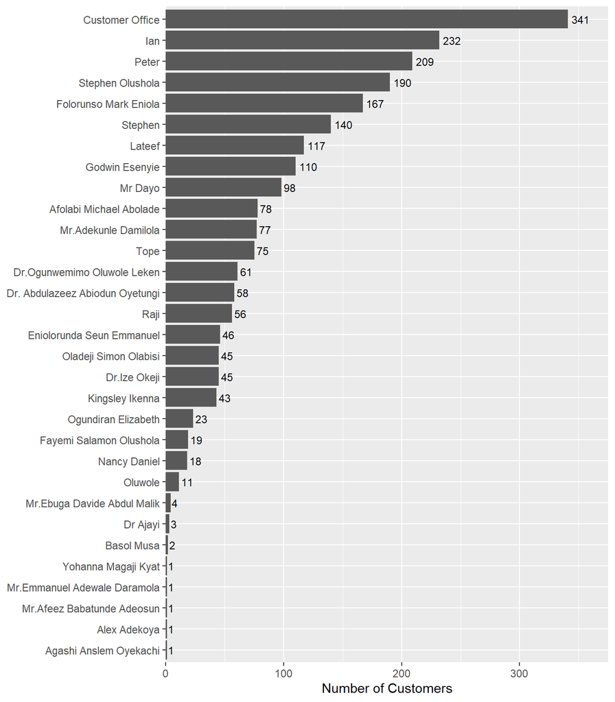

Figure 1: Number of customers managed per sales representative (all reps)

### 3.2 Workload Distribution — Real Reps Only

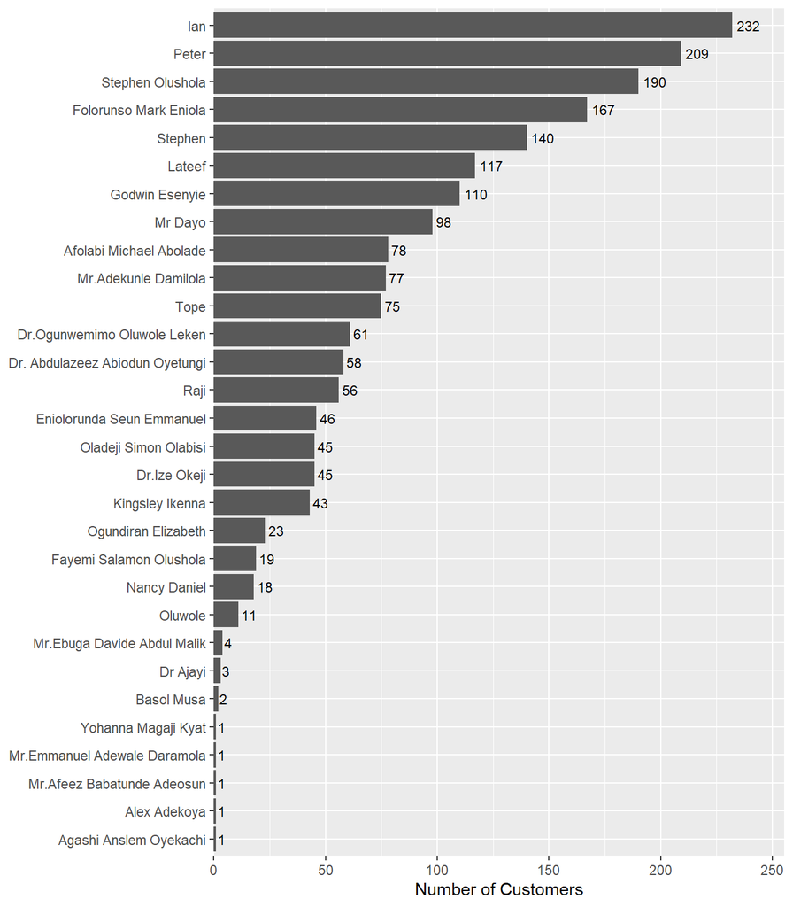

Figure 2: Customer count per rep — excluding ‘Customer Office’ placeholder

## 4 Geographic Distribution

### 4.1 Where Are Our Customers?

Figure 3 shows how customers are distributed across cities and states nationwide, after consolidating inconsistent location entries from the raw database.

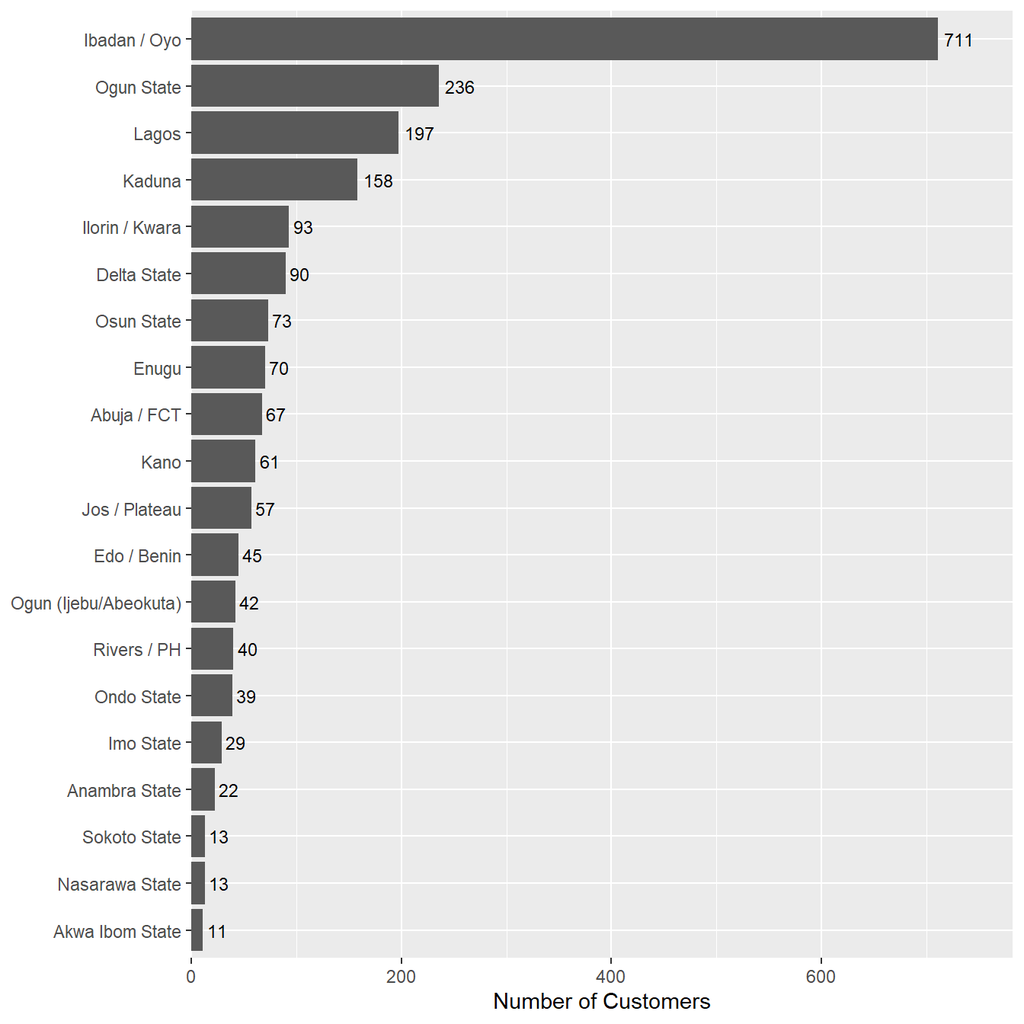

Figure 3: Customer distribution by location — top 20 cities / states

**NoteGeographic Highlights**

- **Ibadan / Oyo** is the dominant market with 711 customers — nearly 3× the next largest location.
- **Ogun State (236), Lagos (197), and Kaduna (158)** form the next tier.
- Southern and middle-belt states hold 70–95 customers each, suggesting broad national reach but thin coverage outside the South-West.

## 5 Regional Coverage by Sales Rep

Figure 4 maps which reps are active in which regions, using the top 10 locations and top 15 reps. Darker cells indicate more customers.

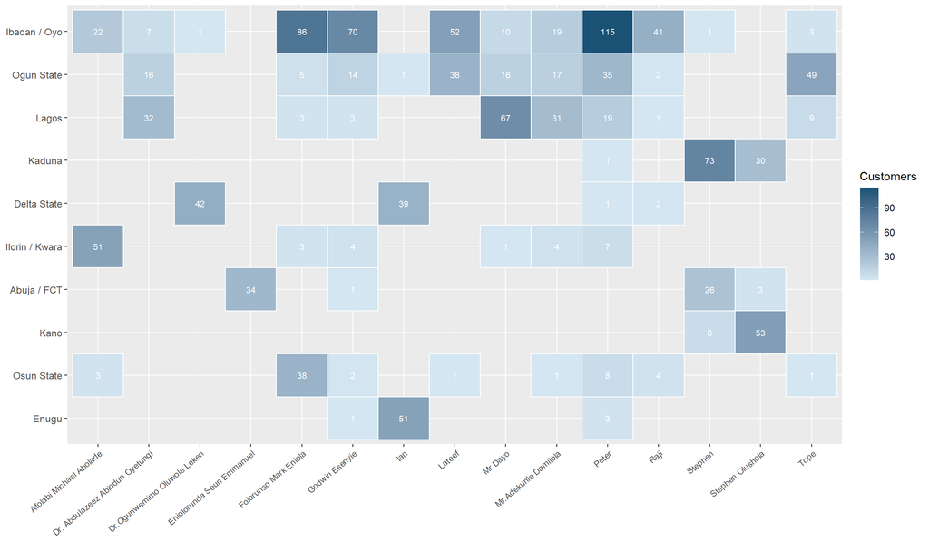

Figure 4: Sales rep coverage heatmap — top 10 regions × top 15 reps

## 6 Key Account Management Risks

### 6.1 Risk Overview

Table 3: Ian vs Peter — Side-by-Side Risk Comparison

| Metric | Ian | Peter |
| --- | --- | --- |
| Total customers managed | 232 | 209 |
| Regions covered | 31 | 22 |
| Regions with only 1 customer | 13 | 13 |
| Largest single region | Enugu — 51 (22%) | Ibadan — 115 (55%) |
| Portfolio concentration | Low (evenly spread) | High (Ibadan-heavy) |
| Geographic coherence | Strong (South-East corridor) | Weak (scattered) |
| Succession difficulty | Very High | High |

### 6.2 Ian — Regional Spread

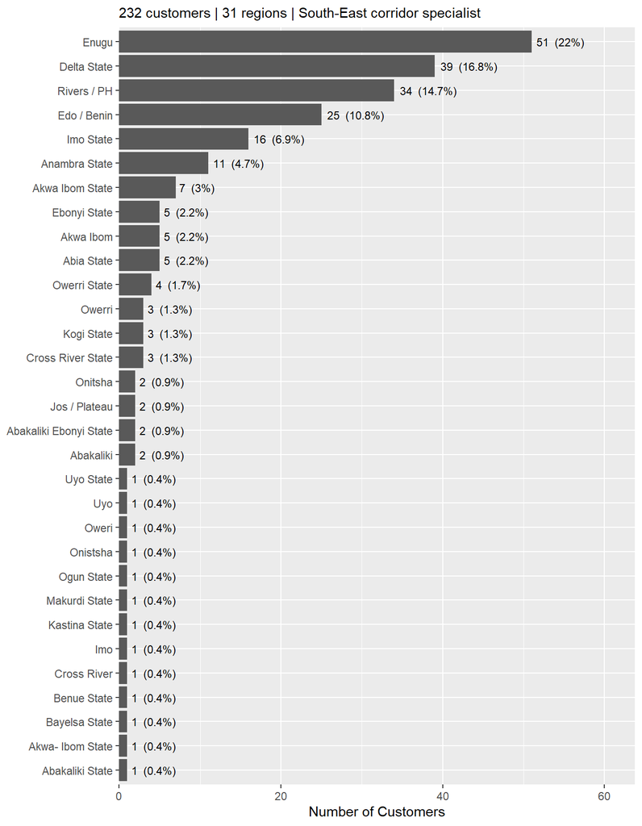

Figure 5: Ian — 232 customers across 31 regions

**ImportantIan Risk Summary**

Ian is the business’s largest rep by customer count. His portfolio spans **31 regions** — the widest of any rep — with **no dominant anchor region** (largest region: Enugu at only 22%). If Ian left, accounts would need to be redistributed across 31 different regions simultaneously, making him the **highest succession risk** in the business.

### 6.3 Peter — Regional Spread

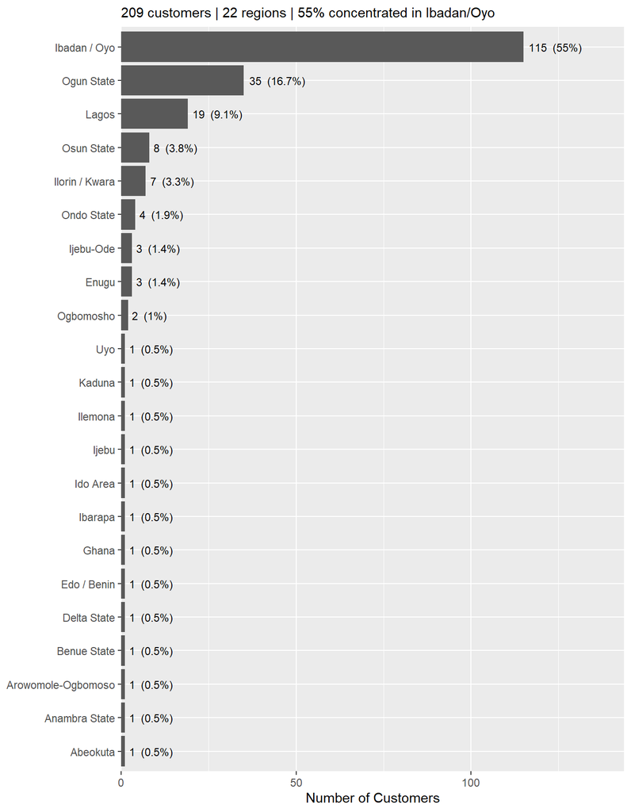

Figure 6: Peter — 209 customers across 22 regions

**ImportantPeter Risk Summary**

Peter manages **115 customers in Ibadan/Oyo alone** — the business’s single largest market (55% of his portfolio). He is also the de facto owner of this territory. Losing Peter would mean the largest customer hub in the database loses its primary relationship manager overnight. His 13 single-customer outlier regions (including Ghana, Kaduna, Benue) are geographically incoherent and likely receiving minimal attention.

## 7 Priority Action Plan for the CEO

Table 4: Recommended Actions — Prioritised for CEO

| Priority | Action | Owner | Suggested Timeline |
| --- | --- | --- | --- |
| 1 | Identify a South-East deputy for Ian across his core 5 regions | CEO / HR | Immediate |
| 2 | Identify a named backup rep for Peter’s 115 Ibadan/Oyo accounts | CEO / HR | Immediate |
| 3 | Assign the 341 ‘Customer Office’ accounts to named sales reps | Sales Manager | Within 1 week |
| 4 | Redistribute Ian and Peter’s 26 combined single-customer outlier regions | Sales Manager | Within 2 weeks |
| 5 | Cap both Ian and Peter’s portfolios at 150 accounts | Sales Manager | Within 1 month |
| 6 | Define formal territory maps for all 31 reps | Sales Manager | Within 1 month |
| 7 | Fill missing street address and phone number gaps (9.3% and 4.7%) | Admin Team | Within 1 month |

## 8 Appendix — Full Sales Rep Summary

Table 5: All Sales Representatives — Customer Count and Notes

| Rank | Rep No. | Sales Rep Name | Customer Count | Note |
| --- | --- | --- | --- | --- |
| 1 | 2 | Customer Office | 341 | Placeholder — 341 customers unassigned |
| 2 | 3 | Ian | 232 | High workload — review capacity |
| 3 | 5 | Peter | 209 | High workload — review capacity |
| 4 | 407 | Stephen Olushola | 190 | High workload — review capacity |
| 5 | 509 | Folorunso Mark Eniola | 167 | High workload — review capacity |
| 6 | 4 | Stephen | 140 |  |
| 7 | 501 | Lateef | 117 |  |
| 8 | 513 | Godwin Esenyie | 110 |  |
| 9 | 6 | Mr Dayo | 98 |  |
| 10 | 512 | Afolabi Michael Abolade | 78 |  |
| 11 | 508 | Mr.Adekunle Damilola | 77 |  |
| 12 | 503 | Tope | 75 |  |
| 13 | 311 | Dr.Ogunwemimo Oluwole Leken | 61 |  |
| 14 | 605 | Dr. Abdulazeez Abiodun Oyetungi | 58 |  |
| 15 | 2000 | Raji | 56 |  |
| 16 | 412 | Eniolorunda Seun Emmanuel | 46 |  |
| 17 | 406 | Dr.Ize Okeji | 45 |  |
| 18 | 606 | Oladeji Simon Olabisi | 45 |  |
| 19 | 322 | Kingsley Ikenna | 43 |  |
| 20 | 502 | Ogundiran Elizabeth | 23 |  |
| 21 | 417 | Fayemi Salamon Olushola | 19 |  |
| 22 | 418 | Nancy Daniel | 18 |  |
| 23 | 2040 | Oluwole | 11 |  |
| 24 | 4080 | Mr.Ebuga Davide Abdul Malik | 4 |  |
| 25 | 2010 | Dr Ajayi | 3 |  |
| 26 | 409 | Basol Musa | 2 |  |
| 27 | 130 | Alex Adekoya | 1 | Single customer — verify rep is active |
| 28 | 170 | Mr.Afeez Babatunde Adeosun | 1 | Single customer — verify rep is active |
| 29 | 413 | Yohanna Magaji Kyat | 1 | Single customer — verify rep is active |
| 30 | 3150 | Agashi Anslem Oyekachi | 1 | Single customer — verify rep is active |
| 31 | 5110 | Mr.Emmanuel Adewale Daramola | 1 | Single customer — verify rep is active |

*Report prepared by the Data Analysis Team | Data current as of 05 June 2026* *Source: shola_clean.xlsx — 2,273 verified customer records*